# IODS course project

## We are going to study the relationships between high/low alcohol consumption and these 4 arbitrarily choosen variables:

- Medu - Mothers level of education (numeric 0-4). 0 is none, 4 is higher education. Hypothesis: Lower alcohol consumption with higher mothers education level.
- abscences - number of school abscences (numeric 0 to 45) Hypothesis: many abscences related to higher alcohol consumption.
- schoolsup - extra educational support (binary yes or no) Hypothesis: need of school support related to higher alcohol consumption.
- failures - number of previous class failure (numeric: range 0-3): Hypothesis: previous failures relates to hihger alcohol consumption.

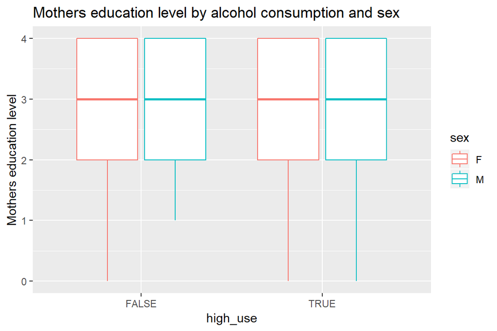

```r
# initialize a plot of high_use and Medu
Meduplot <- ggplot(alc, aes(x = high_use, y = Medu, col = sex))

# define the plot as a boxplot and draw it
Meduplot + geom_boxplot() + ylab("Mothers education level") +ggtitle("Mothers education level by alcohol consumption and sex")
```

No visible difference between students mothers education levels when grouped by high_use.

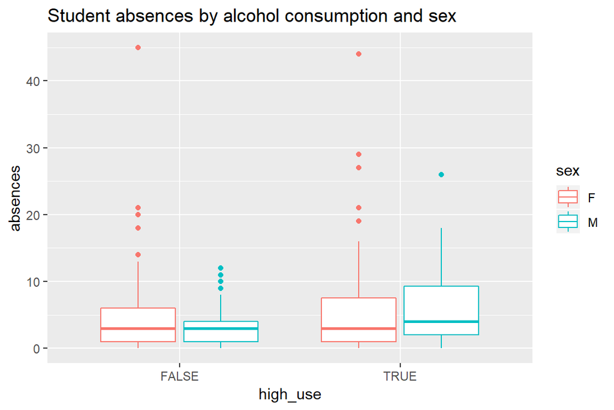

```r
# initialise a plot of high_use and absences
absencesplot <- ggplot(alc, aes(x = high_use, y = absences, col = sex))

# define the plot as a boxplot and draw it
absencesplot +geom_boxplot() + ggtitle("Student absences by alcohol consumption and sex")
```

A tendence towards more abscences with higher alcohol consumption.

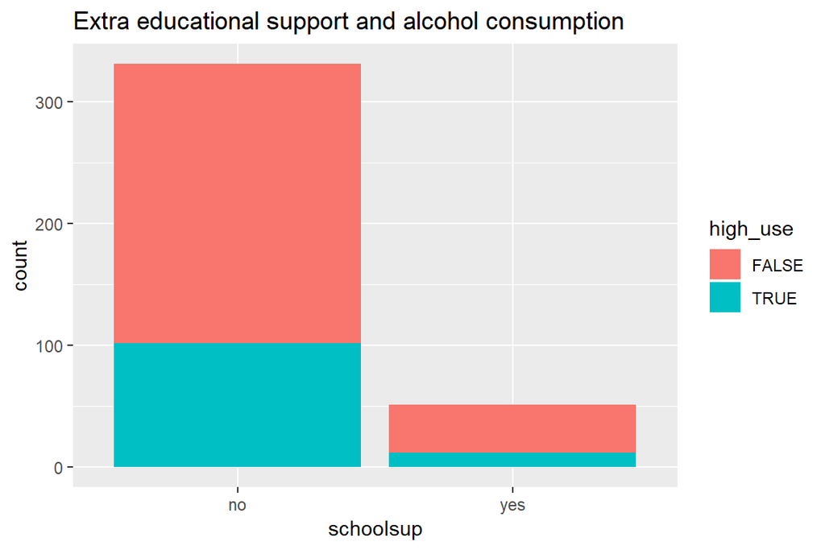

```r
#barplot with number of students
ggplot(data=alc, aes(x=schoolsup, fill=high_use)) + geom_bar() + ggtitle("Extra educational support and alcohol consumption")
```

Proportion of students with high alcohol use seems to be less in the group receiving Extra school support

```r
# Cross-tabulate by failures and high_use
alc %>% group_by(failures, high_use) %>% summarise(count = n())
```

```
## # A tibble: 8 x 3
## # Groups:   failures [?]
##   failures high_use count
##      <int> <lgl>    <int>
## 1        0 FALSE      244
## 2        0 TRUE        90
## 3        1 FALSE       12
## 4        1 TRUE        12
## 5        2 FALSE       10
## 6        2 TRUE         9
## 7        3 FALSE        2
## 8        3 TRUE         3
```

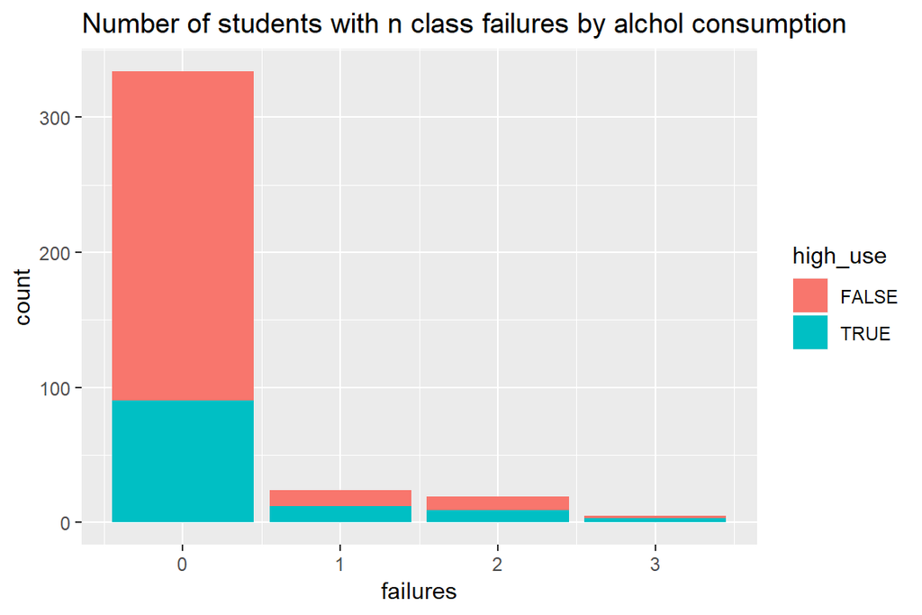

```r
ggplot(data=alc, aes(x=failures, fill=high_use)) + geom_bar() + ggtitle("Number of students with n class failures by alchol consumption")
```

Students with high alcohol consumption are overrepresented in the groups with previous class failures.

## Logistic regression

We use the function glm() to fit a logistic regression model “m” with *high_use* as target, and *Medu*, *abscences*, *schoolsup* and *failures* as predictors and print a summary.

```r
m <- glm(high_use ~ Medu + absences + schoolsup + failures, data = alc, family = "binomial")
summary(m)
```

```
##
## Call:
## glm(formula = high_use ~ Medu + absences + schoolsup + failures,
##     family = "binomial", data = alc)
##
## Deviance Residuals:
##     Min       1Q   Median       3Q      Max
## -2.2871  -0.8081  -0.7056   1.2096   1.9285
##
## Coefficients:
##              Estimate Std. Error z value Pr(>|z|)
## (Intercept)  -1.49792    0.36611  -4.092 4.29e-05 ***
## Medu          0.05863    0.11326   0.518 0.604693
## absences      0.08581    0.02305   3.723 0.000197 ***
## schoolsupyes -0.42697    0.36812  -1.160 0.246102
## failures      0.53531    0.19401   2.759 0.005794 **
## ---
## Signif. codes:  0 '***' 0.001 '**' 0.01 '*' 0.05 '.' 0.1 ' ' 1
##
## (Dispersion parameter for binomial family taken to be 1)
##
##     Null deviance: 465.68  on 381  degrees of freedom
## Residual deviance: 438.37  on 377  degrees of freedom
## AIC: 448.37
##
## Number of Fisher Scoring iterations: 4
```

Abscences and failures are statistically positively associated with high use of alcohol. (p <0.05)

Next we compute odds ratios with confidence intervals from the coefficients of the model with the exp function.

```r
# compute odds ratios
OR <- coef(m) %>% exp

# compute confidence intervals (CI)
CI <- confint(m) %>% exp
# print out the odds ratios with their confidence intervals
cbind(OR, CI)
```

```
##                     OR     2.5 %    97.5 %
## (Intercept)  0.2235938 0.1067127 0.4499919
## Medu         1.0603825 0.8505919 1.3273428
## absences     1.0896003 1.0437001 1.1424496
## schoolsupyes 0.6524844 0.3050016 1.3052315
## failures     1.7079772 1.1703297 2.5182154
```

The confidence intervals for Medu and schoolsup include the number 1 in the 95% confidence interval range, and thus the association with these and alcohol use is not statistically significant, just as we found in the summary of our model previously. OR 1.089 for abscences means that for each additional abscence the odds for high use of alcohol is 8.9% higher. The same goes for class failures, but the odds are even higher OR = 1.708.

## Predictions of the model vs. actual values

Well rebuild the model using the statistically significant predictors failures and abscences, calculate probabilities for each individual and compare them to actual values.

```r
# fit the model
m2 <- glm(high_use ~ failures + absences, data = alc, family = "binomial")

#  predict() the probability of high_use and add the predicted probabilities to 'alc'
alc <- mutate(alc, probability = predict(m2, type = "response"))

# use the probabilities to make a prediction of high_use( true if prob >0.5)
alc <- mutate(alc, prediction = probability > 0.5)

# tabulate the target variable versus the predictions
table(high_use = alc$high_use, prediction = alc$prediction)
```

```
##         prediction
## high_use FALSE TRUE
##    FALSE   258   10
##    TRUE     99   15
```

This gives us 10 false positives, and 99 false negatives out of 382 observations. That gives a probability of 0.2853403 for false classification. Guessing woud give a probability of 0.5, so this model preforms about twice as good as pure guesswork.

# Excercise 4 - Clustering and classification

## Introduction and data

We use the built-in R `Boston` data set which explores housing values in suburbs of Boston.

```r
# load the library MASS, and the data.
library(MASS)
data(Boston)

str(Boston)
```

```
## 'data.frame':    506 obs. of  14 variables:
##  $ crim   : num  0.00632 0.02731 0.02729 0.03237 0.06905 ...
##  $ zn     : num  18 0 0 0 0 0 12.5 12.5 12.5 12.5 ...
##  $ indus  : num  2.31 7.07 7.07 2.18 2.18 2.18 7.87 7.87 7.87 7.87 ...
##  $ chas   : int  0 0 0 0 0 0 0 0 0 0 ...
##  $ nox    : num  0.538 0.469 0.469 0.458 0.458 0.458 0.524 0.524 0.524 0.524 ...
##  $ rm     : num  6.58 6.42 7.18 7 7.15 ...
##  $ age    : num  65.2 78.9 61.1 45.8 54.2 58.7 66.6 96.1 100 85.9 ...
##  $ dis    : num  4.09 4.97 4.97 6.06 6.06 ...
##  $ rad    : int  1 2 2 3 3 3 5 5 5 5 ...
##  $ tax    : num  296 242 242 222 222 222 311 311 311 311 ...
##  $ ptratio: num  15.3 17.8 17.8 18.7 18.7 18.7 15.2 15.2 15.2 15.2 ...
##  $ black  : num  397 397 393 395 397 ...
##  $ lstat  : num  4.98 9.14 4.03 2.94 5.33 ...
##  $ medv   : num  24 21.6 34.7 33.4 36.2 28.7 22.9 27.1 16.5 18.9 ...
```

```r
dim(Boston)
```

```
## [1] 506  14
```

An explanation of the 14 variables can be found [here.](https://stat.ethz.ch/R-manual/R-devel/library/MASS/html/Boston.html) 12 are numeric, `chas` is a binary masked as an integer (0 or 1) and `rad` is an index in integer form (1 to 24). There are 506 observations of each variable.

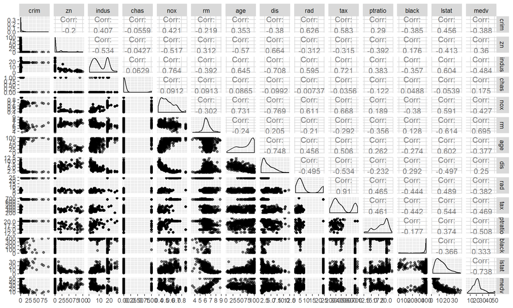

```r
par <- ggpairs(Boston, mapping = aes(alpha = 0.3), lower = list(combo = wrap("facethist", bins = 20)))
par
```

The `ggpairs()` plot contains a lot of information, and is a bit crowded with so many variables althoug you can see some patterns appearing with regards to correlation. Most variables do not seem to be normally distributed. Lets have a look at a colored correlation plot.

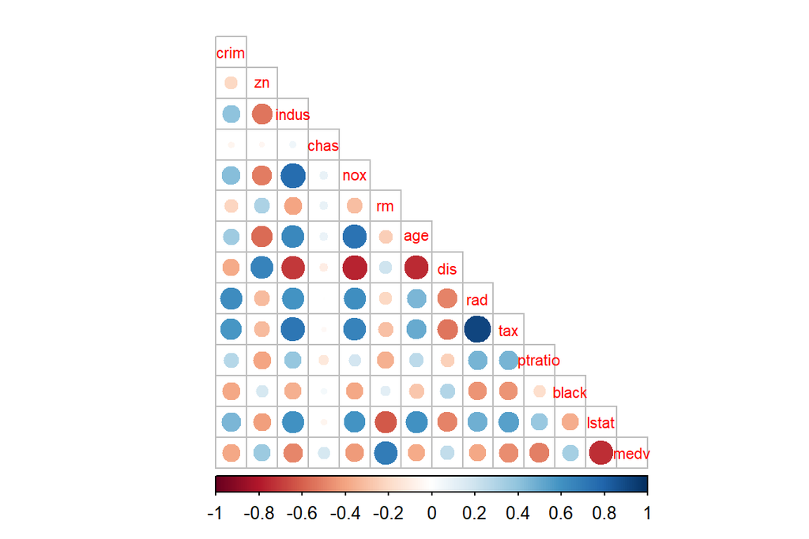

```r
# assign correlation matrix
cor_mtrx <- cor(Boston)
# plot
corrplot(cor_mtrx, method="circle", type="lower", cl.pos="b", tl.pos="d", tl.cex=0.7)
```

This nicely shows correlation between variables. To name a few: `indus` (proportion of land in use of industry) and `nox` (concentration of nitrogen oxides) are positively correlated, and negatively correlated with `dis` (distance to highways). This seems reasonable.

## We´ll standardise the data

```r
# center and standardize variables
boston_scaled <- scale(Boston, center=T, scale=T)

# change matrix to data frame
boston_scaled <- as.data.frame(boston_scaled)

# summaries of the scaled variables
summary(boston_scaled)
```

```
##       crim                 zn               indus
##  Min.   :-0.419367   Min.   :-0.48724   Min.   :-1.5563
##  1st Qu.:-0.410563   1st Qu.:-0.48724   1st Qu.:-0.8668
##  Median :-0.390280   Median :-0.48724   Median :-0.2109
##  Mean   : 0.000000   Mean   : 0.00000   Mean   : 0.0000
##  3rd Qu.: 0.007389   3rd Qu.: 0.04872   3rd Qu.: 1.0150
##  Max.   : 9.924110   Max.   : 3.80047   Max.   : 2.4202
##       chas              nox                rm               age
##  Min.   :-0.2723   Min.   :-1.4644   Min.   :-3.8764   Min.   :-2.3331
##  1st Qu.:-0.2723   1st Qu.:-0.9121   1st Qu.:-0.5681   1st Qu.:-0.8366
##  Median :-0.2723   Median :-0.1441   Median :-0.1084   Median : 0.3171
##  Mean   : 0.0000   Mean   : 0.0000   Mean   : 0.0000   Mean   : 0.0000
##  3rd Qu.:-0.2723   3rd Qu.: 0.5981   3rd Qu.: 0.4823   3rd Qu.: 0.9059
##  Max.   : 3.6648   Max.   : 2.7296   Max.   : 3.5515   Max.   : 1.1164
##       dis               rad               tax             ptratio
##  Min.   :-1.2658   Min.   :-0.9819   Min.   :-1.3127   Min.   :-2.7047
##  1st Qu.:-0.8049   1st Qu.:-0.6373   1st Qu.:-0.7668   1st Qu.:-0.4876
##  Median :-0.2790   Median :-0.5225   Median :-0.4642   Median : 0.2746
##  Mean   : 0.0000   Mean   : 0.0000   Mean   : 0.0000   Mean   : 0.0000
##  3rd Qu.: 0.6617   3rd Qu.: 1.6596   3rd Qu.: 1.5294   3rd Qu.: 0.8058
##  Max.   : 3.9566   Max.   : 1.6596   Max.   : 1.7964   Max.   : 1.6372
##      black             lstat              medv
##  Min.   :-3.9033   Min.   :-1.5296   Min.   :-1.9063
##  1st Qu.: 0.2049   1st Qu.:-0.7986   1st Qu.:-0.5989
##  Median : 0.3808   Median :-0.1811   Median :-0.1449
##  Mean   : 0.0000   Mean   : 0.0000   Mean   : 0.0000
##  3rd Qu.: 0.4332   3rd Qu.: 0.6024   3rd Qu.: 0.2683
##  Max.   : 0.4406   Max.   : 3.5453   Max.   : 2.9865
```

With ´scale()` on default settings we center the data on 0, and divide each variable by its standard deviation, effectively making the SD = 1 for each variable. We do this due to the requirements of *Linear discriminant analysis*.

## Some data wrangling

Now we create a categorical variable for crime rate from the quantiles of `crim`. Also we divide the data into a `train` and `test` set with 80% of data in the train set. Well remove the correct `crime` classes from the test set after saving them separately as `true_crime`.

```r
# create a quantile vector of crim
bins <- quantile(boston_scaled$crim)

# create a categorical variable 'crime' with the quantiles.
lblz <- c("low", "med_low", "med_high","high")
crime <- cut(boston_scaled$crim, breaks = bins, labels = lblz, include.lowest = TRUE)

# remove original crim from the dataset
boston_scaled <- dplyr::select(boston_scaled, -crim)

# add the new categorical value to scaled data
boston_scaled <- data.frame(boston_scaled, crime)

# randomly choose 80% of rows, yields 404 rows.
selection <- sample(nrow(boston_scaled), size = 0.8*nrow(boston_scaled))

#gen train set
train <- boston_scaled[selection,]

#gen test set
test <- boston_scaled[-selection,]

# remove correct classes from test set.
true_crime <- test$crime
test <- dplyr::select(test, -crime)
```

## After this data wrangling we are ready for linear discriminant analysis with `crime` as target variable, and all others as predictors.

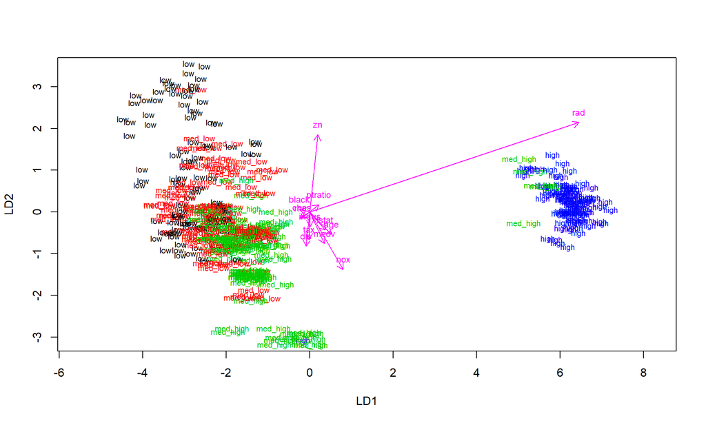

```r
#we fit the modelwith crime
lda.fit <- lda(crime ~ ., data = train)

# we define a function for producing arrows in the plot
lda.arrows <- function(x, myscale = 1, arrow_heads = 0.1, color = "magenta", tex = 0.75, choices = c(1,2)){
  heads <- coef(x)
  arrows(x0 = 0, y0 = 0,
         x1 = myscale * heads[,choices[1]],
         y1 = myscale * heads[,choices[2]], col=color, length = arrow_heads)
  text(myscale * heads[,choices], labels = row.names(heads),
       cex = tex, col=color, pos=3)
}

#
crime_classes <- as.numeric(train$crime) #for colors in plot
plot(lda.fit, col = crime_classes, pch = crime_classes, dimen =2)
lda.arrows(lda.fit, myscale =2)
```

```r
#plot(boston_scaled$crime, boston_scaled$rad)
```

Our first linear discriminant LD1, which is on the x-axis separates the `high` from `low` to `med_high` classes very well, whereas LD2 (y axis) does not do a too good job on this, slthoug separation between `low` and `med_high` is apparent. I guess that our model would be good at predicting wether crime rate is exceptionally high. The predictor with most influence is `rad` (accessibillity to radial highways), followedby `zn` and `nox`.

## We´ll predict classes in the test dataset.

```r
# did the removing of crime from test set already in the chunk "categorize crime"
# predict classes with test data
lda.pred <- predict(lda.fit, newdata = test)

# cross tabulate the results
table(correct = true_crime, predicted = lda.pred$class)
```

```
##           predicted
## correct    low med_low med_high high
##   low       18      11        0    0
##   med_low    8      15        4    0
##   med_high   1       5       17    1
##   high       0       0        0   22
```

The model is able to predict crime rate class pretty well. It has most trouble separating `med_low` from its neighbors.

## And now for some distance measures

We´ll count euclidean distances for the standardised and centered Boston dataset and view a summary of distances. Then well run kmeans on the data with 4 clusters, and have a look at an example plot with some of the variables.

```r
data(Boston)
centbost <- scale(Boston, center=T, scale=T)
dist_eu <- dist(centbost)
summary(dist_eu)
```

```
##    Min. 1st Qu.  Median    Mean 3rd Qu.    Max.
##  0.1343  3.4625  4.8241  4.9111  6.1863 14.3970
```

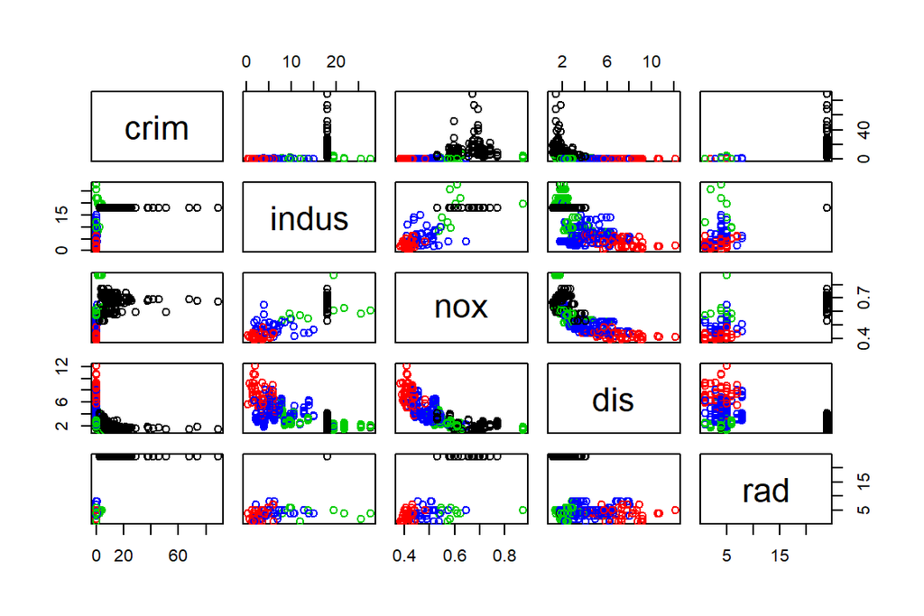

```r
#run kmeans
km <- kmeans(centbost, centers = 4)

#plot
pairs(Boston[c(1,3,5,8,9)], col = km$cluster)
```

We´ll calculate the otpimum number of clusters by looking at within cluster sum of squares based on how many clusters we use. We plot wcss by number of clusters, and the optimum number of clusters should be where wcss drops radically.

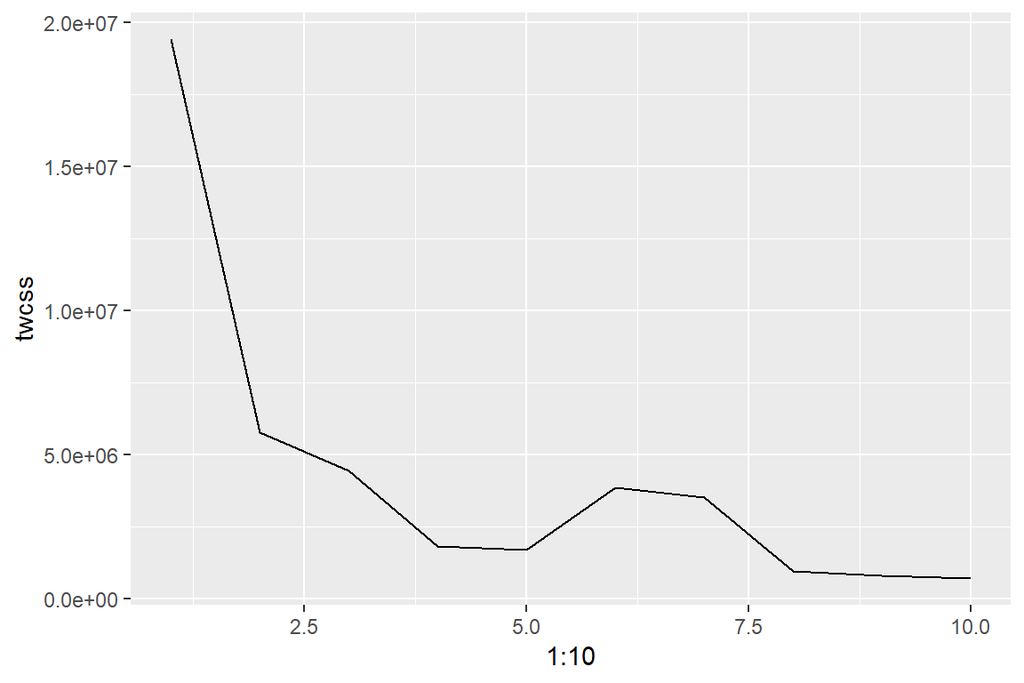

```r
# calculate the total within sum of squares
twcss <- sapply(1:10, function(k){kmeans(Boston, k)$tot.withinss})

# visualize the results
qplot(x = 1:10, y = twcss, geom = 'line')
```

Two in this case. Well run the kmeans with 2 centers, and plot the pairs in Boston coloring by these centers.

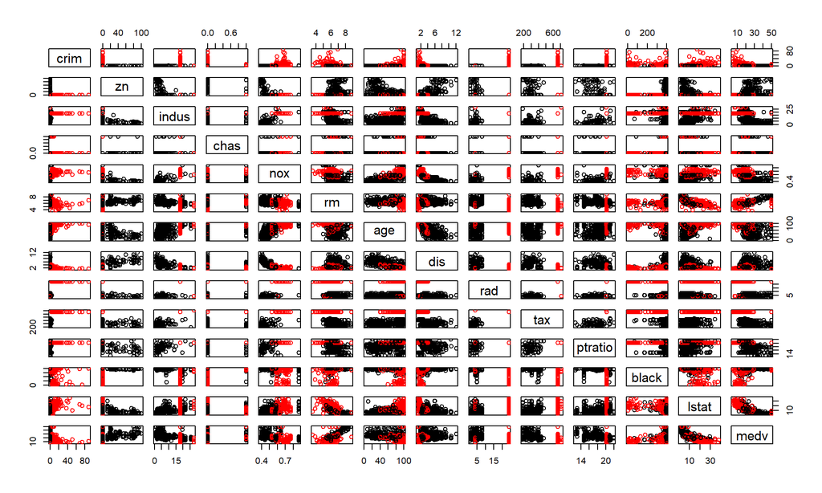

```r
# k-means clustering
km2 <-kmeans(Boston, centers = 2)

# plot the Boston dataset with clusters
pairs(Boston, col = km2$cluster)
```

## Let´s try the Bonus excercise:

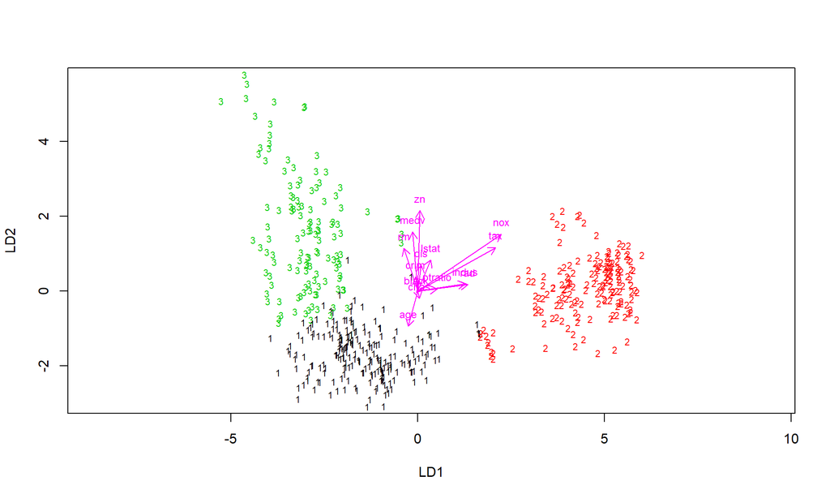

```r
data(Boston)
BBoston <- as.data.frame(scale(Boston, center=T, scale=T)) # center and scale, as data frame


#run kmeans
kmB <- kmeans(BBoston, centers = 3)

#we fit the modelwith crime
lda.fit <- lda(kmB$cluster ~ ., data = BBoston)

# we define a function for producing arrows in the plot
lda.arrows <- function(x, myscale = 1, arrow_heads = 0.1, color = "magenta", tex = 0.75, choices = c(1,2)){
  heads <- coef(x)
  arrows(x0 = 0, y0 = 0,
         x1 = myscale * heads[,choices[1]],
         y1 = myscale * heads[,choices[2]], col=color, length = arrow_heads)
  text(myscale * heads[,choices], labels = row.names(heads),
       cex = tex, col=color, pos=3)
}

#
# crime_classes <- as.numeric(train$crime) #for colors in plot
plot(lda.fit, col = kmB$cluster, dimen =2)
lda.arrows(lda.fit, myscale =2)
```

# Excercise 5 - Dimensionality reduction techniques

## Introduction and data

We are using the `human` dataset, which originates from the United Nations Development Programme. This dataset has `8` variables and `155` observations, all of which are different countries. The variables and descriptions are shown below.

| Variable | Explanation |
| --- | --- |
| mat.mort | Maternal mortality |
| ado.BR | Adolescent birth rate |
| parl.rep | Female share of parliamentary seats |
| eduratio | Ratio of F to M with secondary education |
| laboratio | Ratio of F to M in labour force |
| life.exp | Life expectancy at birth |
| edu.exp | Excpected years of schooling |
| GNI.pc | Gross national income per capita |

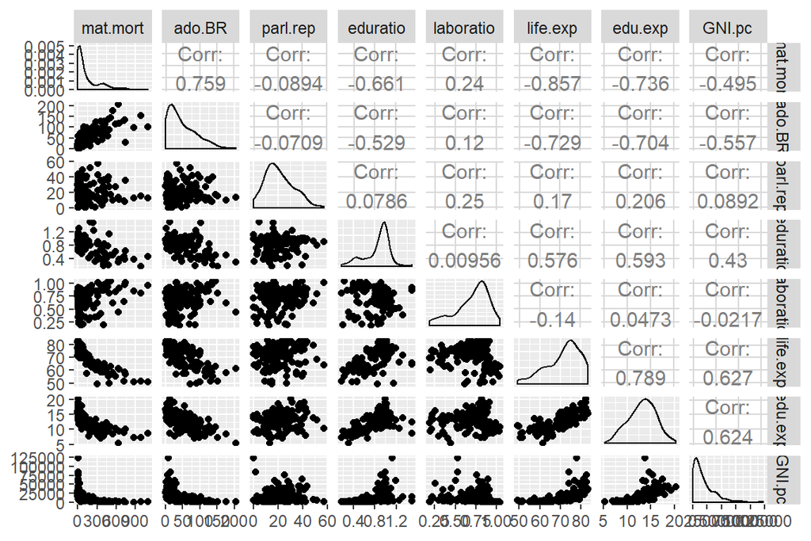

```r
ggpairs(human)
```

Distribution of most variables look skewed, except for `edu.exp` which seems normally distributed. There are also a bunch of apparent correlations between variables, eg. `edu.exp` and `life.exp`

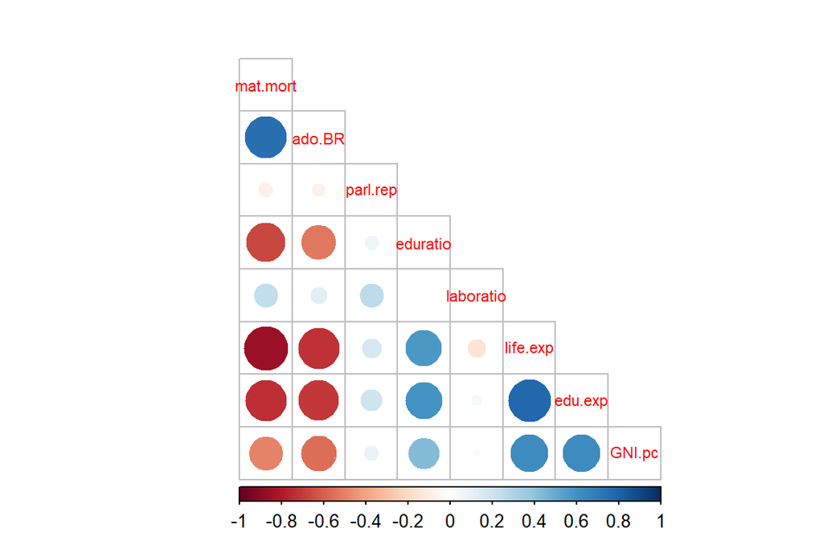

```r
corrplot(cor(human), method="circle", type="lower", cl.pos="b", tl.pos="d", tl.cex=0.7)
```

The correlations are better visualized here. For example: Strong correlation between *Maternal mortality* and *Adolescent birth rate.*

```r
humansummary <- summary(human)
kable(humansummary)
```

|  | mat.mort | ado.BR | parl.rep | eduratio | laboratio | life.exp | edu.exp | GNI.pc |
| --- | --- | --- | --- | --- | --- | --- | --- | --- |
|  | Min. : 1.0 | Min. : 0.60 | Min. : 0.00 | Min. :0.1717 | Min. :0.1857 | Min. :49.00 | Min. : 5.40 | Min. : 581 |
|  | 1st Qu.: 11.5 | 1st Qu.: 12.65 | 1st Qu.:12.40 | 1st Qu.:0.7264 | 1st Qu.:0.5984 | 1st Qu.:66.30 | 1st Qu.:11.25 | 1st Qu.: 4198 |
|  | Median : 49.0 | Median : 33.60 | Median :19.30 | Median :0.9375 | Median :0.7535 | Median :74.20 | Median :13.50 | Median : 12040 |
|  | Mean : 149.1 | Mean : 47.16 | Mean :20.91 | Mean :0.8529 | Mean :0.7074 | Mean :71.65 | Mean :13.18 | Mean : 17628 |
|  | 3rd Qu.: 190.0 | 3rd Qu.: 71.95 | 3rd Qu.:27.95 | 3rd Qu.:0.9968 | 3rd Qu.:0.8535 | 3rd Qu.:77.25 | 3rd Qu.:15.20 | 3rd Qu.: 24512 |
|  | Max. :1100.0 | Max. :204.80 | Max. :57.50 | Max. :1.4967 | Max. :1.0380 | Max. :83.50 | Max. :20.20 | Max. :123124 |

Above are summaries of variables. Maternal mortality is n/100000 births, and Adolescent birth rate is births / 1000 females aged 15-19.

## Principal component analysis

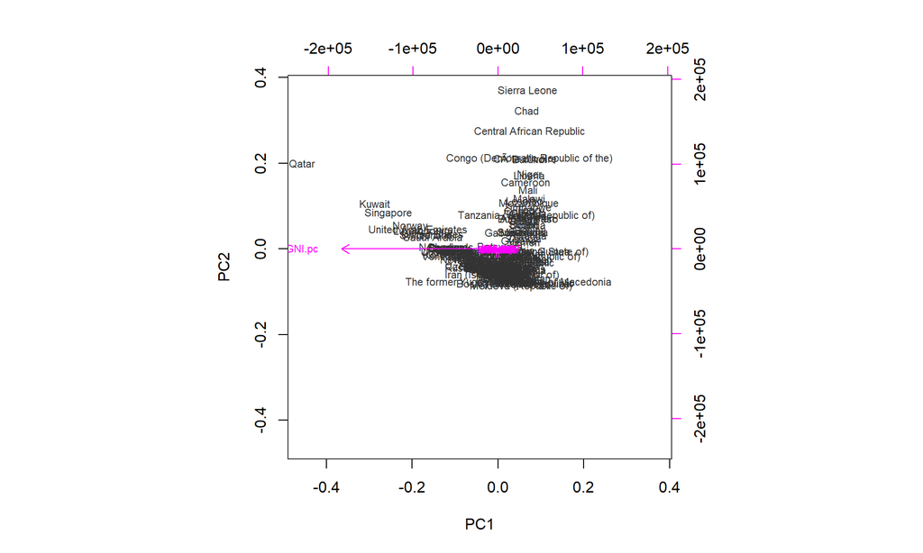

```r
#perform PCA on unscaled human data
pca_human1 <- prcomp(human)

# draw a biplot of the principal component representation and the original variables
biplot(pca_human1, choices = 1:2, cex = c(0.7, 0.7), col = c("grey20", "magenta"))
```

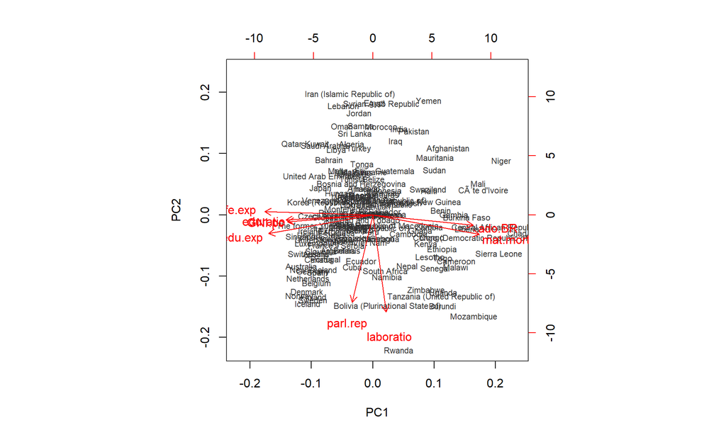

```r
#scale with default options (center to 0 and divide by SD)
human2 <- scale(human)
#perform PCA on scaled human data
pca_human2 <- prcomp(human2)

# draw a biplot of the principal component representation and the original variables
biplot(pca_human2, choices = 1:2, cex = c(0.7, 1.0), col = c("grey20", "red"))
```

This looks better. Principal component 1 is affected by 6 out of 8 variables in the data to a similar degree. Adolescent birth rate and maternal mortality are positively correlated, but negatively correlated with the following group of phenomenons, (which again are positively correlated): life expectancy, education expectancy, ratio of females to males receiving secondary education, and GNI per capita. Uncorrelated with the previous, but correlated with eachother are percentage of females in parliament, and ratio of females to males in the labour force. These two affect the secondary principal component.

So i conclude that GNI, and availability of education - for both genders are positively correlated with life expectancy, and adolescent births and maternal mortality are inversely correlated with these. Percentage of females in the work force and as representatives in parliament are not correlated with the phenomenons above.

## Tea Time

We have a look at questionnaire data regarding consumption of tea. The data is included in the `FactomineR` package. I choose a few variables wich would be interesting for me as a tearoom owner. Structure of the chosen data and a summary are seen below.

```r
library(FactoMineR)
library(tidyr)
data(tea)

keeptea=c("Tea","sugar","tea.time","tearoom","SPC","sex","resto","pub","How","how","friends")

# select the 'keeptea' to create a new dataset
tea_kept <- dplyr::select(tea, one_of(keeptea))

# look at the summaries and structure of the data

summary(tea_kept)
```

```
##         Tea           sugar             tea.time          tearoom
##  black    : 74   No.sugar:155   Not.tea time:131   Not.tearoom:242
##  Earl Grey:193   sugar   :145   tea time    :169   tearoom    : 58
##  green    : 33
##
##
##
##
##            SPC     sex           resto          pub         How
##  employee    :59   F:178   Not.resto:221   Not.pub:237   alone:195
##  middle      :40   M:122   resto    : 79   pub    : 63   lemon: 33
##  non-worker  :64                                         milk : 63
##  other worker:20                                         other:  9
##  senior      :35
##  student     :70
##  workman     :12
##                  how             friends
##  tea bag           :170   friends    :196
##  tea bag+unpackaged: 94   Not.friends:104
##  unpackaged        : 36
##
##
##
##
```

```r
str(tea_kept)
```

```
## 'data.frame':    300 obs. of  11 variables:
##  $ Tea     : Factor w/ 3 levels "black","Earl Grey",..: 1 1 2 2 2 2 2 1 2 1 ...
##  $ sugar   : Factor w/ 2 levels "No.sugar","sugar": 2 1 1 2 1 1 1 1 1 1 ...
##  $ tea.time: Factor w/ 2 levels "Not.tea time",..: 1 1 2 1 1 1 2 2 2 1 ...
##  $ tearoom : Factor w/ 2 levels "Not.tearoom",..: 1 1 1 1 1 1 1 1 1 2 ...
##  $ SPC     : Factor w/ 7 levels "employee","middle",..: 2 2 4 6 1 6 5 2 5 5 ...
##  $ sex     : Factor w/ 2 levels "F","M": 2 1 1 2 2 2 2 1 2 2 ...
##  $ resto   : Factor w/ 2 levels "Not.resto","resto": 1 1 2 1 1 1 1 1 1 1 ...
##  $ pub     : Factor w/ 2 levels "Not.pub","pub": 1 1 1 1 1 1 1 1 1 1 ...
##  $ How     : Factor w/ 4 levels "alone","lemon",..: 1 3 1 1 1 1 1 3 3 1 ...
##  $ how     : Factor w/ 3 levels "tea bag","tea bag+unpackaged",..: 1 1 1 1 1 1 1 1 2 2 ...
##  $ friends : Factor w/ 2 levels "friends","Not.friends": 2 2 1 2 2 2 1 2 2 2 ...
```

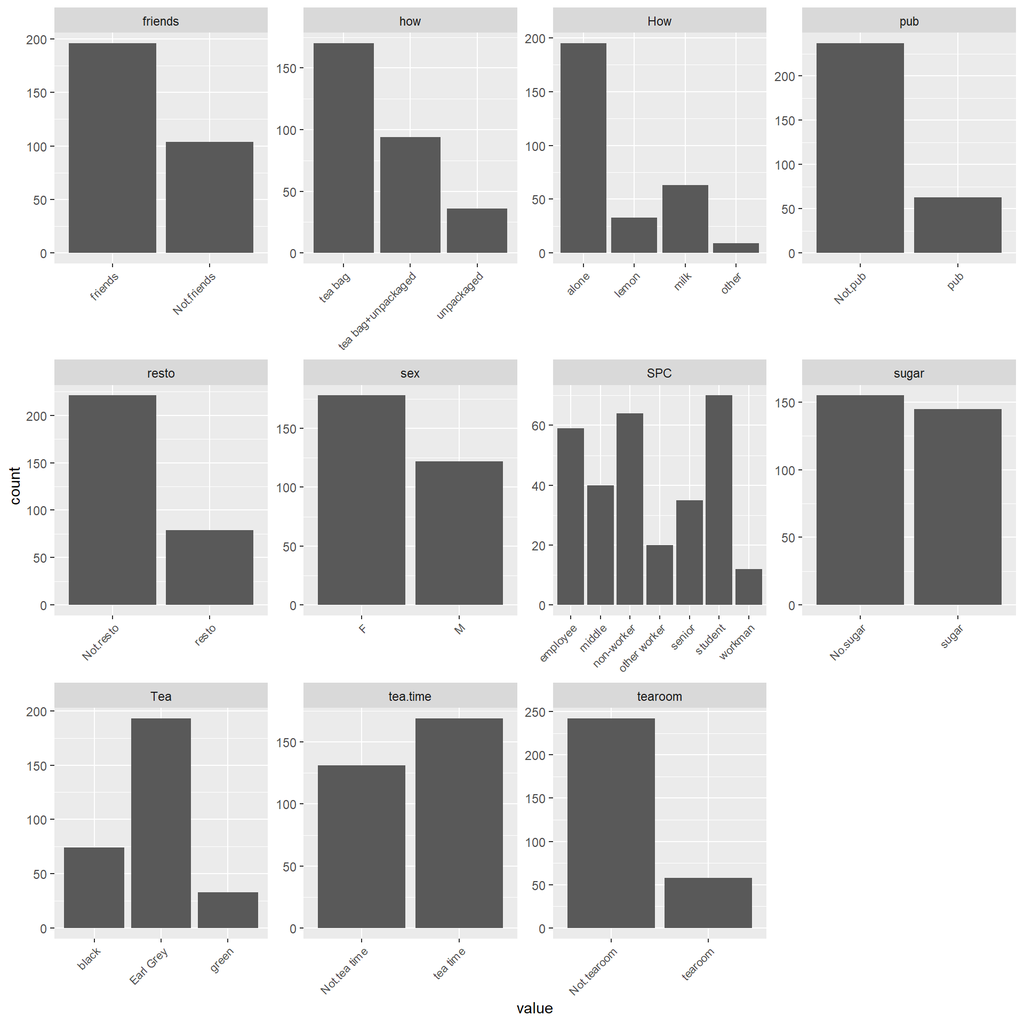

```r
# visualize the dataset
gather(tea_kept) %>% ggplot(aes(value)) +geom_bar() + facet_wrap("key", scales = "free") + theme(axis.text.x = element_text(angle = 45, hjust = 1, size = 8))
```

## Multiple correspondence analysis

Let´s do a multiple correspondence analysis on the kept data.

```r
# multiple correspondence analysis
mca <- MCA(tea_kept, graph = FALSE)

# summary of the model
summary(mca)
```

```
##
## Call:
## MCA(X = tea_kept, graph = FALSE)
##
##
## Eigenvalues
##                        Dim.1   Dim.2   Dim.3   Dim.4   Dim.5   Dim.6
## Variance               0.195   0.151   0.132   0.114   0.110   0.105
## % of var.             10.708   8.322   7.281   6.276   6.039   5.789
## Cumulative % of var.  10.708  19.030  26.312  32.588  38.627  44.415
##                        Dim.7   Dim.8   Dim.9  Dim.10  Dim.11  Dim.12
## Variance               0.100   0.094   0.091   0.088   0.082   0.077
## % of var.              5.482   5.175   5.008   4.822   4.487   4.241
## Cumulative % of var.  49.897  55.072  60.080  64.902  69.389  73.631
##                       Dim.13  Dim.14  Dim.15  Dim.16  Dim.17  Dim.18
## Variance               0.075   0.072   0.069   0.063   0.057   0.053
## % of var.              4.114   3.941   3.796   3.463   3.129   2.890
## Cumulative % of var.  77.745  81.686  85.482  88.945  92.074  94.965
##                       Dim.19  Dim.20
## Variance               0.048   0.043
## % of var.              2.657   2.379
## Cumulative % of var.  97.621 100.000
##
## Individuals (the 10 first)
##                 Dim.1    ctr   cos2    Dim.2    ctr   cos2    Dim.3    ctr
## 1            | -0.726  0.903  0.333 |  0.356  0.280  0.080 |  0.058  0.008
## 2            | -0.472  0.381  0.124 |  0.547  0.660  0.167 | -0.255  0.164
## 3            |  0.344  0.203  0.059 | -0.054  0.006  0.001 | -0.038  0.004
## 4            | -0.606  0.629  0.345 | -0.417  0.384  0.164 |  0.189  0.090
## 5            | -0.610  0.637  0.331 | -0.066  0.010  0.004 | -0.086  0.019
## 6            | -0.525  0.472  0.262 | -0.236  0.123  0.053 | -0.065  0.011
## 7            | -0.088  0.013  0.006 |  0.105  0.024  0.009 |  0.253  0.161
## 8            | -0.235  0.095  0.032 |  0.552  0.672  0.175 | -0.370  0.344
## 9            | -0.128  0.028  0.009 |  0.383  0.323  0.081 |  0.452  0.515
## 10           | -0.026  0.001  0.000 |  0.767  1.296  0.273 |  0.247  0.154
##                cos2
## 1             0.002 |
## 2             0.036 |
## 3             0.001 |
## 4             0.034 |
```

[output cut: 28 more lines]

```
## tearoom        4.470 |   0.037   0.018   0.000   0.312 |
## employee      -2.590 |  -0.244   0.802   0.015  -2.085 |
##
## Categorical variables (eta2)
##                Dim.1 Dim.2 Dim.3
## Tea          | 0.103 0.469 0.069 |
## sugar        | 0.039 0.150 0.257 |
## tea.time     | 0.323 0.000 0.052 |
## tearoom      | 0.389 0.067 0.000 |
## SPC          | 0.076 0.485 0.305 |
## sex          | 0.190 0.064 0.351 |
## resto        | 0.284 0.016 0.159 |
## pub          | 0.198 0.075 0.002 |
## How          | 0.121 0.167 0.213 |
## how          | 0.169 0.131 0.031 |
```

Look at the summary of the MCA. The first and second dimensions account for 10.7% and 8.3% of variance, respectively.

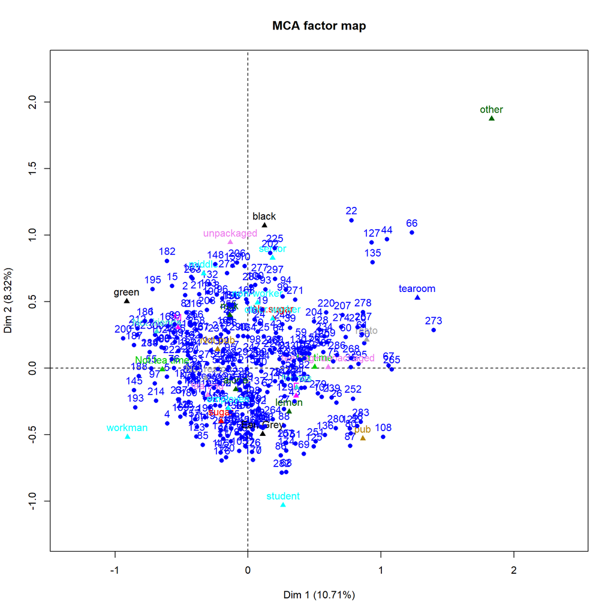

```r
# visualize MCA

plot(mca, habillage = "quali")
```

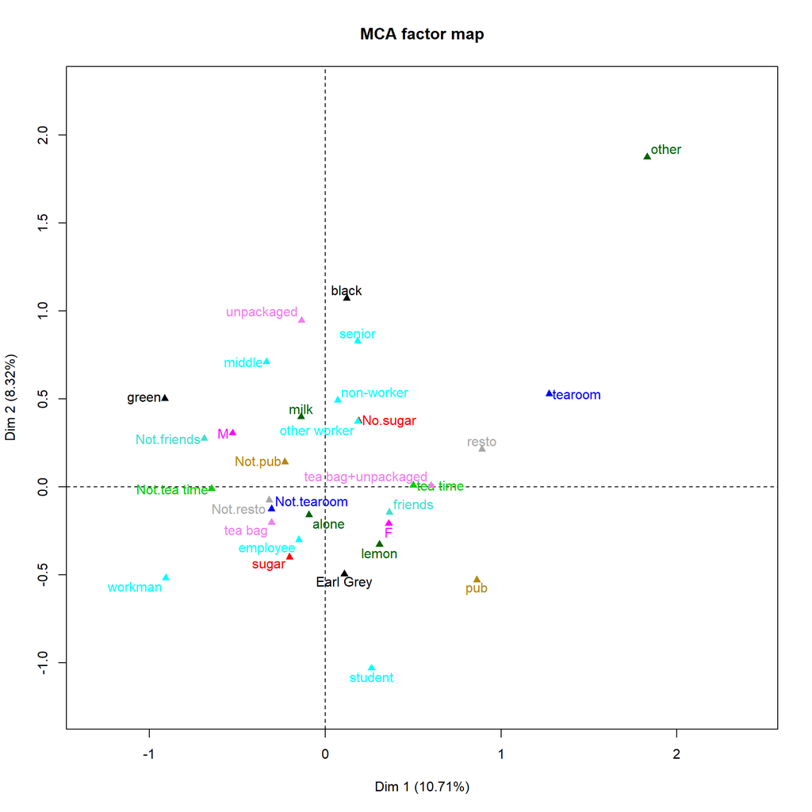

```r
plot(mca, invisible=c("ind") ,habillage="quali")
```

From the first plot we can see a homogenous blob of individuals, with only one small group of outliers (22, 44, 66, 127, and 135)

In the second plot the individuals are hidden, and we can see that dim. 1 opposes public places that sell tea, i.e `tearooms`, `restaurants` and `pubs` with `**not** tearooms, restaurants and pubs.` in dim. 2 `earl grey` is opposed with `black tea`, just as `seniors`, `middle`, and `non-workers`, which are opposed with `students`. `other` is a strong determinant in both dimensions.

I find that ´Earl Grey´, ´Lemon´, ´F´ and ´Friends´ are grouped together. Maybe promoting **Two Earl Grey tea:s with lemon for the price of one!** could bring new customers to my tearoom?

```r
keeprows = c(22,44,66,127,135)
outliers <- tea_kept[keeprows, ]
outliers
```

```
##       Tea    sugar     tea.time     tearoom        SPC sex     resto
## 22  black No.sugar Not.tea time     tearoom non-worker   F     resto
## 44  black No.sugar     tea time     tearoom non-worker   F     resto
## 66  black No.sugar     tea time     tearoom non-worker   F     resto
## 127 black No.sugar     tea time Not.tearoom     senior   F     resto
## 135 black No.sugar     tea time     tearoom     middle   F Not.resto
##         pub   How                how     friends
## 22  Not.pub other tea bag+unpackaged Not.friends
## 44  Not.pub other            tea bag     friends
## 66  Not.pub other tea bag+unpackaged     friends
## 127 Not.pub other tea bag+unpackaged     friends
## 135     pub other            tea bag     friends
```

Finally a look at the group of outliers mentioned previously. The distinguishing features seem to be that they all drink black tea without sugar, but with the `other` (vs `lemon`, `milk`, and `alone`) attribute, which is quite uncommon, only 9 out of 300 individuals.

# Excercise 6 - Longitudinal data.

## MABS chapter 8 analyses on RATS data

In the `RATSL` data we have 16 individual rats in 3 feeding `Group`s with different diets. The rats are followed for ~8 weeks (`Time`in days). The `Weight` of the rats is measured. There are 176 weight measurements in total.

```r
dim(RATSL)
```

```
## [1] 176   5
```

```r
summary(RATSL)
```

```
##        ID      Group        WD         Weight           Time
##  1      : 11   1:88   WD1    :16   Min.   :225.0   Min.   : 1.00
##  2      : 11   2:44   WD15   :16   1st Qu.:267.0   1st Qu.:15.00
##  3      : 11   3:44   WD22   :16   Median :344.5   Median :36.00
##  4      : 11          WD29   :16   Mean   :384.5   Mean   :33.55
##  5      : 11          WD36   :16   3rd Qu.:511.2   3rd Qu.:50.00
##  6      : 11          WD43   :16   Max.   :628.0   Max.   :64.00
##  (Other):110          (Other):80
```

We´ll plot the individual weight curves:

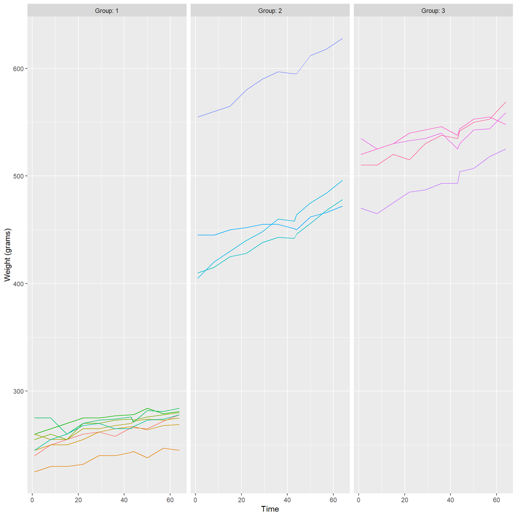

```r
ggplot(RATSL, aes(x = Time, y = Weight, colour = ID)) +
  geom_line() +
  facet_grid(. ~ Group, labeller = label_both) +
  theme(legend.position = "none") +
  scale_y_continuous(limits = c(min(RATSL$Weight), max(RATSL$Weight)), name="Weight (grams)")
```

There are some clearly visible differences in starting weights between groups. Group 1 rats weigh less than group 2 and 3. All weights tend to increase with time. The slope in group 1 is not as steep as in groups 2 or 3.

We´ll standardize the data and do the same plot again.

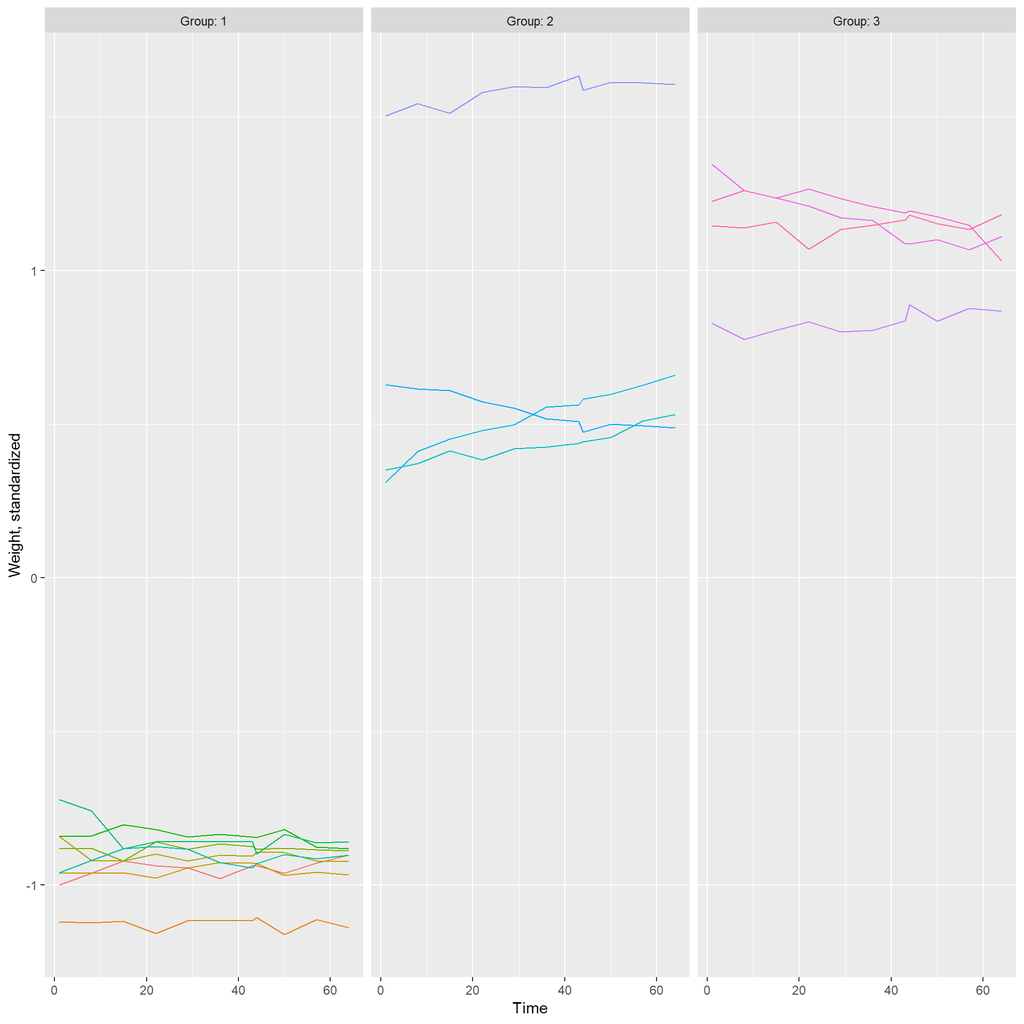

```r
RATSL <- RATSL %>%
  group_by(Time) %>%
  mutate(stdWeight = (Weight - mean(Weight))/sd(Weight)) %>%
 # mutate(sclWeight = scale(Weight)) %>% #scale does the same thing as we learned earlier.
  ungroup()

ggplot(RATSL, aes(x = Time, y = stdWeight, colour = ID)) +
  geom_line() +
  facet_grid(. ~ Group, labeller = label_both) +
  theme(legend.position = "none") +
  scale_y_continuous(limits = c(min(RATSL$stdWeight), max(RATSL$stdWeight)), name="Weight, standardized")
```

In plot on standardized values we see that most lines are approximately horizontal, and this goes for all groups. Fat rats stay fat and slim rats stay slim, relatively speaking, althoug the absolute weight values increased as we saw in the first plot. This is called the `tracking phenomenon.

We now plot mean weights of groups + SEM

```r
# Number of measurement points, baseline included
n <- RATSL$Time %>% unique() %>% length()

# Summary data with mean and standard error of bprs by treatment and week
RATSSummary <- RATSL %>%
  group_by(Group, Time) %>%
  summarise( mean = mean(Weight), se = (sd(Weight)/sqrt(n))) %>%
  ungroup()

# Glimpse the data
glimpse(RATSSummary)
```

```
## Observations: 33
## Variables: 4
## $ Group <fct> 1, 1, 1, 1, 1, 1, 1, 1, 1, 1, 1, 2, 2, 2, 2, 2, 2, 2, 2,...
## $ Time  <int> 1, 8, 15, 22, 29, 36, 43, 44, 50, 57, 64, 1, 8, 15, 22, ...
## $ mean  <dbl> 250.625, 255.000, 254.375, 261.875, 264.625, 265.000, 26...
## $ se    <dbl> 4.589478, 3.947710, 3.460116, 4.100800, 3.333956, 3.5529...
```

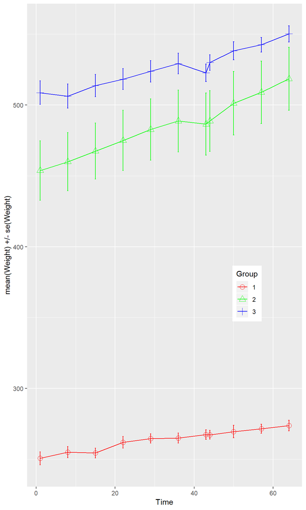

```r
# Plot the mean profiles
ggplot(RATSSummary, aes(x = Time, y = mean, color = Group, shape = Group)) +
  geom_line() +
  scale_colour_manual(values = c("red","green","blue")) +
  geom_point(size=3) +
  scale_shape_manual(values = c(1,2,3)) +
  geom_errorbar(aes(ymin=mean-se, ymax=mean+se, linetype=NULL), width=0.3) +
  theme(legend.position = c(0.8,0.4)) +
  scale_y_continuous(name = "mean(Weight) +/- se(Weight)")
```

The groups are each on their own weight tracks which differ from eachother. Perhaps group 2 approaches group 3 somewhat? As starting weights are different between groups, and probably infuelnceweight gain i want to look at relative weight gain compared to day 1. We calculate it in percentage of weight compared to initial weight and plot it in the same manner as above.

### Relative weights

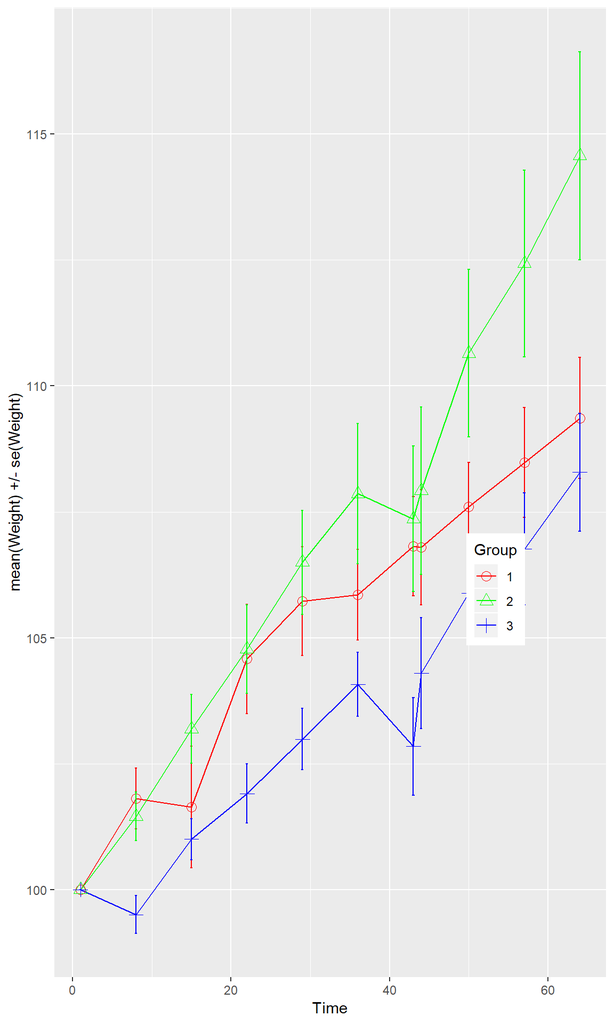

```r
# I want to look at relative weight increase when compared to starting weights, and calculate it with the following command:

RATSL <- RATSL %>%
  group_by(ID,Group) %>%
  mutate(Weight_rel = Weight/Weight[Time == 1]*100)

# Number of measurement points, baseline included
n <- RATSL$Time %>% unique() %>% length()

# Summary data with mean and standard error of bprs by treatment and week
RATSSummary_rel <- RATSL %>%
  group_by(Group, Time) %>%
  summarise( mean = mean(Weight_rel), se = (sd(Weight_rel)/sqrt(n))) %>%
  ungroup()

# Plot the mean profiles
ggplot(RATSSummary_rel, aes(x = Time, y = mean, color = Group, shape = Group)) +
  geom_line() +
  scale_colour_manual(values = c("red","green","blue")) +
  geom_point(size=3) +
  scale_shape_manual(values = c(1,2,3)) +
  geom_errorbar(aes(ymin=mean-se, ymax=mean+se, linetype=NULL), width=0.3) +
  theme(legend.position = c(0.8,0.4)) +
  scale_y_continuous(name = "mean(Weight) +/- se(Weight)")
```

The relative weight gains are quite similar, but group 2 seems to gain weight a little faster. Lets boxplot this after removing baseline measurements

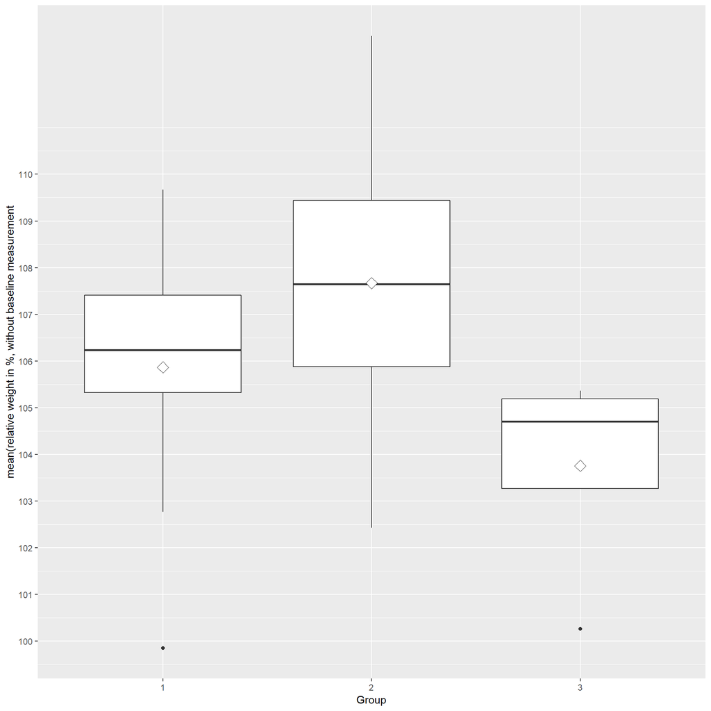

```r
RATSLBs <- RATSL %>%
  filter(Time > 1) %>%
  group_by(Group, ID) %>%
  summarise(mean=mean(Weight_rel)) %>%
  ungroup()

# Draw a boxplot of the mean versus Group
ggplot(RATSLBs, aes(x = Group, y = mean)) +
  geom_boxplot() +
  stat_summary(fun.y = "mean", geom = "point", shape=23, size=4, fill = "white") +
  scale_y_continuous(name = "mean(relative weight in %, without baseline measurement", breaks=seq(100,110,1))
```

I´m happy with the plot, the difference seems to persist between G2 and G3. Let´s test.

```r
# Add the baseline (100) to the summary data
RATSLBs <- RATSLBs %>%
  mutate(baseline = 100)

# Fit the linear model with the mean as the response
fit <- lm(mean ~ baseline + Group, data = RATSLBs)

# Compute the analysis of variance table for the fitted model with anova()

anova(fit)
```

```
## Analysis of Variance Table
##
## Response: mean
##           Df  Sum Sq Mean Sq F value Pr(>F)
## Group      2  30.729  15.365   1.371 0.2882
## Residuals 13 145.685  11.207
```

The anova gives us p =0.29. This tells us that no significant differences in relative weight gains exist between groups.

### Actual weights

We do the same with actual weights.

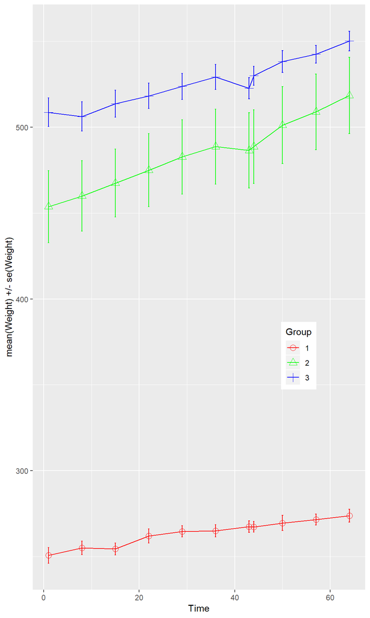

```r
# Number of measurement points, baseline included
n <- RATSL$Time %>% unique() %>% length()

# Summary data with mean and standard error of bprs by treatment and week
RATSSummary_abs <- RATSL %>%
  group_by(Group, Time) %>%
  summarise( mean = mean(Weight), se = (sd(Weight)/sqrt(n))) %>%
  ungroup()

# Plot the mean profiles
ggplot(RATSSummary_abs, aes(x = Time, y = mean, color = Group, shape = Group)) +
  geom_line() +
  scale_colour_manual(values = c("red","green","blue")) +
  geom_point(size=3) +
  scale_shape_manual(values = c(1,2,3)) +
  geom_errorbar(aes(ymin=mean-se, ymax=mean+se, linetype=NULL), width=0.3) +
  theme(legend.position = c(0.8,0.4)) +
  scale_y_continuous(name = "mean(Weight) +/- se(Weight)")
```

This graph we saw before. Lets boxplot mean weight without baseline measurements.

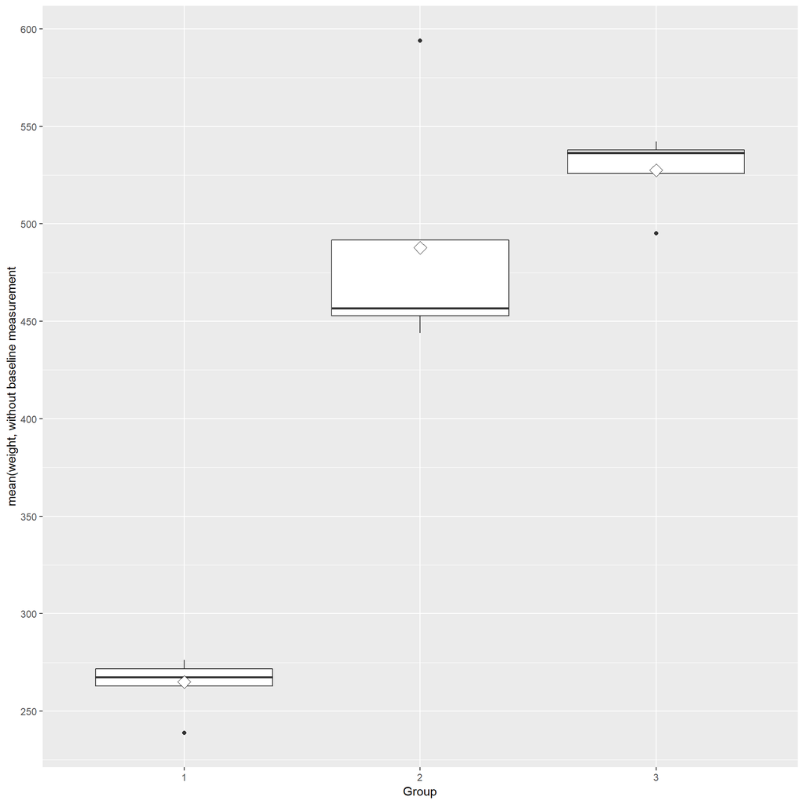

```r
RATSLBsabs <- RATSL %>%
  filter(Time > 1) %>%
  group_by(Group, ID) %>%
  summarise(mean=mean(Weight)) %>%
  ungroup()

# Draw a boxplot of the mean versus Group
ggplot(RATSLBsabs, aes(x = Group, y = mean)) +
  geom_boxplot() +
  stat_summary(fun.y = "mean", geom = "point", shape=23, size=4, fill = "white") +
  scale_y_continuous(name = "mean(weight, without baseline measurement", breaks=seq(200,700,50))
```

```r
# Add the baseline from time = 1 to the summary data
RATSLBsabs <- RATSLBsabs %>%
  mutate(baseline2 = RATSL$Weight[RATSL$Time == 1])
# Fit the linear model with the mean as the response to variables baseline2 and group in both orders.
fitabs <- lm(mean ~  Group + baseline2, data = RATSLBsabs)
fitabs2 <- lm(mean ~ baseline2 + Group, data = RATSLBsabs)
# Compute the analysis of variance table for the fitted models with anova()
summary(fitabs)
```

```
##
## Call:
## lm(formula = mean ~ Group + baseline2, data = RATSLBsabs)
##
## Residuals:
##     Min      1Q  Median      3Q     Max
## -23.905  -4.194   2.190   7.577  14.800
##
## Coefficients:
##             Estimate Std. Error t value Pr(>|t|)
## (Intercept) 33.16375   21.87657   1.516   0.1554
## Group2      34.85753   18.82308   1.852   0.0888 .
## Group3      23.67526   23.25324   1.018   0.3287
## baseline2    0.92513    0.08572  10.793 1.56e-07 ***
## ---
## Signif. codes:  0 '***' 0.001 '**' 0.01 '*' 0.05 '.' 0.1 ' ' 1
##
## Residual standard error: 11.68 on 12 degrees of freedom
## Multiple R-squared:  0.9936, Adjusted R-squared:  0.992
## F-statistic: 622.1 on 3 and 12 DF,  p-value: 1.989e-13
```

```r
summary(fitabs2)
```

```
##
## Call:
## lm(formula = mean ~ baseline2 + Group, data = RATSLBsabs)
##
## Residuals:
##     Min      1Q  Median      3Q     Max
## -23.905  -4.194   2.190   7.577  14.800
##
## Coefficients:
##             Estimate Std. Error t value Pr(>|t|)
## (Intercept) 33.16375   21.87657   1.516   0.1554
## baseline2    0.92513    0.08572  10.793 1.56e-07 ***
## Group2      34.85753   18.82308   1.852   0.0888 .
## Group3      23.67526   23.25324   1.018   0.3287
## ---
## Signif. codes:  0 '***' 0.001 '**' 0.01 '*' 0.05 '.' 0.1 ' ' 1
##
## Residual standard error: 11.68 on 12 degrees of freedom
## Multiple R-squared:  0.9936, Adjusted R-squared:  0.992
## F-statistic: 622.1 on 3 and 12 DF,  p-value: 1.989e-13
```

```r
anova(fitabs)
```

```
## Analysis of Variance Table
##
## Response: mean
##           Df Sum Sq Mean Sq F value    Pr(>F)
## Group      2 238620  119310  874.89 9.986e-14 ***
## baseline2  1  15884   15884  116.48 1.562e-07 ***
## Residuals 12   1636     136
## ---
## Signif. codes:  0 '***' 0.001 '**' 0.01 '*' 0.05 '.' 0.1 ' ' 1
```

```r
anova(fitabs2)
```

```
## Analysis of Variance Table
##
## Response: mean
##           Df Sum Sq Mean Sq   F value   Pr(>F)
## baseline2  1 253625  253625 1859.8201 1.57e-14 ***
## Group      2    879     439    3.2219  0.07586 .
## Residuals 12   1636     136
## ---
## Signif. codes:  0 '***' 0.001 '**' 0.01 '*' 0.05 '.' 0.1 ' ' 1
```

## MABS chapter 9 analyses on BPRS data.

We read the BPRS data in long form, factorize `subject`and `treatment` variables. and have a look at the data. Later i realized there is a danger in the data: Subjects are numbered 1-20 in each treatment group, but in the MABS book it was clearly stated that there were 40 men in the data. Therefore we paste ´subject´ and ´treatment´ to create a new factor variable, subject 2 which we use to separate the 40 individuals. This has significance in creating the random effects models.

```r
BPRSL <- read.table("data/BPRSL.txt")

BPRSL$subject <- factor(BPRSL$subject)
BPRSL$treatment <- factor(BPRSL$treatment)
BPRSL <- mutate(BPRSL, subject2=factor(paste(BPRSL$subject, BPRSL$treatment)))
str(BPRSL)
```

```
## 'data.frame':    360 obs. of  6 variables:
##  $ treatment: Factor w/ 2 levels "1","2": 1 1 1 1 1 1 1 1 1 1 ...
##  $ subject  : Factor w/ 20 levels "1","2","3","4",..: 1 2 3 4 5 6 7 8 9 10 ...
##  $ weeks    : Factor w/ 9 levels "week0","week1",..: 1 1 1 1 1 1 1 1 1 1 ...
##  $ bprs     : int  42 58 54 55 72 48 71 30 41 57 ...
##  $ week     : int  0 0 0 0 0 0 0 0 0 0 ...
##  $ subject2 : Factor w/ 40 levels "1 1","1 2","10 1",..: 1 23 27 29 31 33 35 37 39 3 ...
```

```r
summary(BPRSL)
```

```
##  treatment    subject        weeks          bprs            week
##  1:180     1      : 18   week0  : 40   Min.   :18.00   Min.   :0
##  2:180     2      : 18   week1  : 40   1st Qu.:27.00   1st Qu.:2
##            3      : 18   week2  : 40   Median :35.00   Median :4
##            4      : 18   week3  : 40   Mean   :37.66   Mean   :4
##            5      : 18   week4  : 40   3rd Qu.:43.00   3rd Qu.:6
##            6      : 18   week5  : 40   Max.   :95.00   Max.   :8
##            (Other):252   (Other):120
##     subject2
##  1 1    :  9
##  1 2    :  9
##  10 1   :  9
##  10 2   :  9
##  11 1   :  9
##  11 2   :  9
##  (Other):306
```

The data consists of values of Brief Psychiatric Rating Scale (BPRS) in 40 men in 2 treatment groups followed up for 8 weeks and baseline (week 0) A plot of the data is seen below. For the plot we group data by `ìnteraction(subject,treatment)`

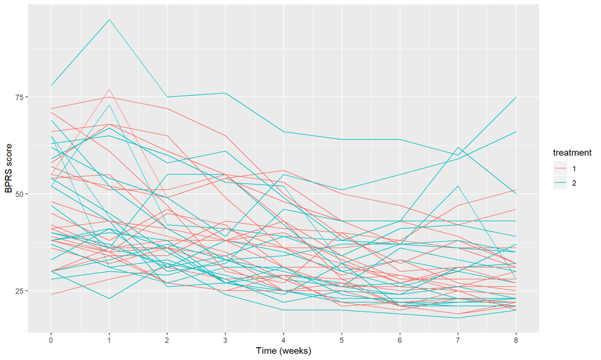

```r
ggplot(BPRSL, aes(x = week, y = bprs, group = subject2)) +
  geom_line(aes(colour = treatment)) + scale_x_continuous(name = "Time (weeks)", breaks = seq(0, 8, 1)) +
  #facet_grid(. ~ treatment, labeller = label_both) +
  scale_y_continuous(name = "BPRS score") +
  theme(legend.position = "right")
```

We´ll ignore that the data consists of repeated measures, and fit a multiple linear regression model with `bprs` as response, and `week` and `treatment` as explanatory variables.

```r
bprs_lrm <- lm(bprs ~ week + treatment, BPRSL)
# print out a summary of the model
summary(bprs_lrm)
```

```
##
## Call:
## lm(formula = bprs ~ week + treatment, data = BPRSL)
##
## Residuals:
##     Min      1Q  Median      3Q     Max
## -22.454  -8.965  -3.196   7.002  50.244
##
## Coefficients:
##             Estimate Std. Error t value Pr(>|t|)
## (Intercept)  46.4539     1.3670  33.982   <2e-16 ***
## week         -2.2704     0.2524  -8.995   <2e-16 ***
## treatment2    0.5722     1.3034   0.439    0.661
## ---
## Signif. codes:  0 '***' 0.001 '**' 0.01 '*' 0.05 '.' 0.1 ' ' 1
##
## Residual standard error: 12.37 on 357 degrees of freedom
## Multiple R-squared:  0.1851, Adjusted R-squared:  0.1806
## F-statistic: 40.55 on 2 and 357 DF,  p-value: < 2.2e-16
```

Ignoring the longitudinal nature of the data the linear regression model indicates that treatment has no effect, whereas with increasing weeks bprs scores decrease by approximately 2.27/week.

### Random intercept

We´ll now fit a *random intercept model* using the package ´lme4´ with `week` and `treatment` as explanatory variables, and `subject` as random effect to account for differences in individuals intercept ~ starting values of bprs scores.

```r
# Create a random intercept model
BPRS_rim <- lmer(bprs ~ week + treatment + (1 | subject2), data = BPRSL, REML = FALSE)

# Print the summary of the model
summary(BPRS_rim)
```

```
## Linear mixed model fit by maximum likelihood  ['lmerMod']
## Formula: bprs ~ week + treatment + (1 | subject2)
##    Data: BPRSL
##
##      AIC      BIC   logLik deviance df.resid
##   2582.9   2602.3  -1286.5   2572.9      355
##
## Scaled residuals:
##      Min       1Q   Median       3Q      Max
## -2.27506 -0.59909 -0.06104  0.44226  3.15835
##
## Random effects:
##  Groups   Name        Variance Std.Dev.
##  subject2 (Intercept) 97.39    9.869
##  Residual             54.23    7.364
## Number of obs: 360, groups:  subject2, 40
##
## Fixed effects:
##             Estimate Std. Error t value
## (Intercept)  46.4539     2.3521  19.750
## week         -2.2704     0.1503 -15.104
## treatment2    0.5722     3.2159   0.178
##
## Correlation of Fixed Effects:
##            (Intr) week
## week       -0.256
## treatment2 -0.684  0.000
```

The estimated slope is still -2.27, but std. error is slightly lower 0.15 vs. 0.25. Treatment still has no effect.

### Random intercept and random slope

Then we fit a random intercept *and* random slope model to also account for individuals random slopes in bprs scores vs. time.

```r
# create a random intercept and random slope model
BPRS_rism <- lmer(bprs ~ week + treatment + (week | subject2), data = BPRSL, REML = FALSE)

# print a summary of the model
summary(BPRS_rism)
```

```
## Linear mixed model fit by maximum likelihood  ['lmerMod']
## Formula: bprs ~ week + treatment + (week | subject2)
##    Data: BPRSL
##
##      AIC      BIC   logLik deviance df.resid
##   2523.2   2550.4  -1254.6   2509.2      353
##
## Scaled residuals:
##     Min      1Q  Median      3Q     Max
## -2.4655 -0.5150 -0.0920  0.4347  3.7353
##
## Random effects:
##  Groups   Name        Variance Std.Dev. Corr
##  subject2 (Intercept) 167.827  12.955
##           week          2.331   1.527   -0.67
##  Residual              36.747   6.062
## Number of obs: 360, groups:  subject2, 40
##
## Fixed effects:
##             Estimate Std. Error t value
## (Intercept)  45.9830     2.6470  17.372
## week         -2.2704     0.2713  -8.370
## treatment2    1.5139     3.1392   0.482
##
## Correlation of Fixed Effects:
##            (Intr) week
## week       -0.545
## treatment2 -0.593  0.000
```

```r
# perform an ANOVA test on the two models
anova(BPRS_rim, BPRS_rism)
```

```
## Data: BPRSL
## Models:
## BPRS_rim: bprs ~ week + treatment + (1 | subject2)
## BPRS_rism: bprs ~ week + treatment + (week | subject2)
##           Df    AIC    BIC  logLik deviance  Chisq Chi Df Pr(>Chisq)
## BPRS_rim   5 2582.9 2602.3 -1286.5   2572.9
## BPRS_rism  7 2523.2 2550.4 -1254.6   2509.2 63.663      2  1.499e-14 ***
## ---
## Signif. codes:  0 '***' 0.001 '**' 0.01 '*' 0.05 '.' 0.1 ' ' 1
```

We get a chi squared of 63.6 with 2 degrees of freedom, and a p of 1.499e-14 indicating that this model with random intercepts and slopes for different subjects is a better fit than the previous model with only random intercepts.

### Random intercept and random slope with interaction of time and treatment

And finally a random intercept and random slope model with the interaction of time and treatment.

```r
# create a random intercept and random slope model with the interaction
BPRS_rismi <- lmer(bprs ~ week * treatment + (week | subject2), data = BPRSL, REML = FALSE)

# print a summary of the model
summary(BPRS_rismi)
```

```
## Linear mixed model fit by maximum likelihood  ['lmerMod']
## Formula: bprs ~ week * treatment + (week | subject2)
##    Data: BPRSL
##
##      AIC      BIC   logLik deviance df.resid
##   2523.5   2554.5  -1253.7   2507.5      352
##
## Scaled residuals:
##     Min      1Q  Median      3Q     Max
## -2.4747 -0.5256 -0.0866  0.4435  3.7884
##
## Random effects:
##  Groups   Name        Variance Std.Dev. Corr
##  subject2 (Intercept) 164.207  12.814
##           week          2.203   1.484   -0.66
##  Residual              36.747   6.062
## Number of obs: 360, groups:  subject2, 40
##
## Fixed effects:
##                 Estimate Std. Error t value
## (Intercept)      47.8856     2.9840  16.047
## week             -2.6283     0.3752  -7.006
## treatment2       -2.2911     4.2201  -0.543
## week:treatment2   0.7158     0.5306   1.349
##
## Correlation of Fixed Effects:
##             (Intr) week   trtmn2
## week        -0.668
## treatment2  -0.707  0.473
## wek:trtmnt2  0.473 -0.707 -0.668
```

```r
# perform an ANOVA test on the two models
anova(BPRS_rismi, BPRS_rism)
```

```
## Data: BPRSL
## Models:
## BPRS_rism: bprs ~ week + treatment + (week | subject2)
## BPRS_rismi: bprs ~ week * treatment + (week | subject2)
##            Df    AIC    BIC  logLik deviance Chisq Chi Df Pr(>Chisq)
## BPRS_rism   7 2523.2 2550.4 -1254.6   2509.2
## BPRS_rismi  8 2523.5 2554.6 -1253.7   2507.5  1.78      1     0.1821
```

The model with an interaction of time and treatment is not significantly better than the previous one. (p = 0.18) Thus finally we plot the original plot with measured bprs and a plot with fitted values from the random slope + intercept model without interaction of time and treatment.

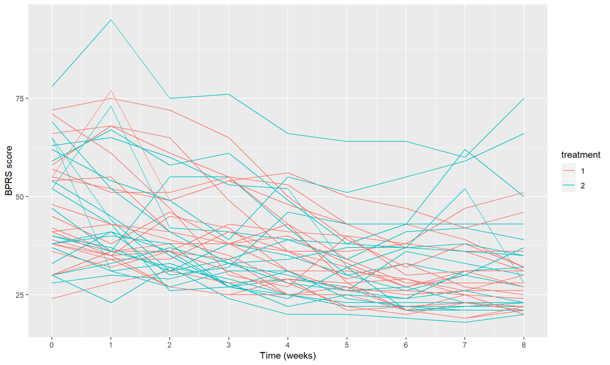

```r
# draw the plot of BPRSL with the observed bprs scores
ggplot(BPRSL, aes(x = week, y = bprs, group = subject2)) +
  geom_line(aes(colour = treatment)) +
  scale_x_continuous(name = "Time (weeks)", breaks = seq(0, 8, 1)) +
  scale_y_continuous(name = "BPRS score") +
  theme(legend.position = "right")
```

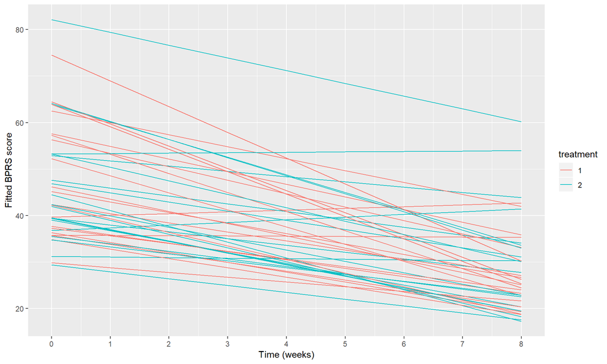

```r
# Create a vector of the fitted values
Fitted <- fitted(BPRS_rism)
# Create a new column fitted to BPRSL

BPRSL <- mutate(BPRSL, FittedBPRS = Fitted)
# draw the plot of BPRSL with the Fitted values of bprs scores
ggplot(BPRSL, aes(x = week, y = FittedBPRS, group = subject2)) +
  geom_line(aes(colour = treatment)) +
  scale_x_continuous(name = "Time (weeks)", breaks = seq(0, 8, 1)) +
  scale_y_continuous(name = "Fitted BPRS score") +
  theme(legend.position = "right")
```

Graphically this is not as demonstrative of a good fit as with the RATS data in the book and datacamp excercises. However, I think a downwards trend in bprs scores can be seen clearlier in the fitted data than in the actual data.

That´s it. It has been an interesting adventure into R, and i have become more proficient in R. Which was the main goal.